# Trabajo Fin de Master 2022/2023

Master en Bioinformática, Universidad de Murcia

2024-04-25

# 1 Enriquecimiento de los datos

A continuación, procederemos a enriquecer los datos obtenidos tras la elaboración de cada uno de los cuatro modelos de regresión Lasso desarrollados anteriormente. Estos modelos, denominados “lasso.mod”, “lasso.mod_pca”, “lasso.mod_f” y “lasso.mod_pca_f”, representan distintas variantes de análisis de los datos.

```r
lasso.mod <- readRDS("lasso.mod.rds")
lasso.mod_pca <- readRDS("lasso.mod_pca.rds")
lasso.mod_f <- readRDS("lasso.mod_f.rds")
lasso.mod_pca_f <- readRDS("lasso.mod_pca_f.rds")

#Base de datos del genoma humano utilizado como referencia
organism <- org.Hs.eg.db
```

Con estos modelos como punto de partida, procederemos a realizar el enriquecimiento de los datos para obtener una mejor comprensión de las funciones biológicas y vías metabólicas asociadas con las variables predictoras seleccionadas en cada uno de los modelos.

## 1.1 Enriquecimiento de los datos obtenido mediante modelo Lasso

A partir del modelo de regresión Lasso denominado “lasso.mod”, se llevará a cabo el enriquecimiento de los datos obtenidos. Para ello, en primer lugar, se seleccionarán las variables que han tenido un mayor peso en la elaboración del modelo.

```r
# Obtención de los coeficientes de las variables relevantes para el modelo
coef_mod <- coef(lasso.mod, s = "lambda.min")
coef_mod_vector <- as.vector(coef_mod)
posiciones_coef_mod <- which(coef_mod != 0)
posiciones_coef_mod <- posiciones_coef_mod[-1]

# Crear un dataframe con los predictores
variables_mod <- as.data.frame(rownames(coef_mod))
colnames(variables_mod) <- "Variables"

# Añadir los coeficientes correspondientes
variables_mod$Coeficientes <- coef_mod_vector

# Filtrar las variables que se encuentran en nuestro modelo
predictoresLasso <- variables_mod[posiciones_coef_mod, ]
predictoresLasso <- predictoresLasso[order(abs(predictoresLasso$Coeficientes), decreasing = TRUE), ]
predictoresLasso
```

|  | Variables | Coeficientes |
| --- | --- | --- |
| 992 | LINC01004 | 2.287702e-01 |
| 77 | AKAP9 | 1.417967e-01 |
| 204 | B4GALT6 | 8.453190e-02 |
| 1596 | RNF123 | -7.018556e-02 |
| 1239 | NMRK1 | -6.979375e-02 |
| 1208 | NEBL | -6.798585e-02 |
| 2027 | TTLL5 | -6.464788e-02 |
| 2206 | ZDHHC14 | -5.909857e-02 |
| 641 | EXTL3 | 5.773643e-02 |
| 766 | GLYR1 | -5.031801e-02 |

[output cut: 70 more lines]

```r
#Obtencion de los ENTREZID de los genes presentes en el modelo
entrez_ids <- select(org.Hs.eg.db, keys=predictoresLasso$Variables, keytype="SYMBOL", column="ENTREZID")
posiciones_genes <- as.numeric(entrez_ids$ENTREZID)
```

A continuación, utilizaremos el paquete ‘ClusterProfiler’ para llevar a cabo el enriquecimiento de los datos. Este análisis identifica las funciones biológicas enriquecidas asociadas con un conjunto de genes de interés. En particular, se utilizará la función ‘enrichGO()’ para el enriquecimiento basado en la ontología génica (GO) utilizando la base de datos “org.Hs.eg.db” correspondiente al genoma humano. Luego, se mostrará un resumen de los resultados, proporcionando una visión general de las funciones biológicas enriquecidas.

```r
eGOLasso <- enrichGO(gene = posiciones_genes,
                     OrgDb = organism,
                     pvalueCutoff = 1,
                     keyType = "ENTREZID",
                     ont = "all"
)
eGOLasso
```

```
## #
## # over-representation test
## #
## #...@organism     Homo sapiens
## #...@ontology     GOALL
## #...@keytype      ENTREZID
## #...@gene     chr [1:74] "100216546" "10142" "9331" "63891" "54981" "10529" "23093" ...
## #...pvalues adjusted by 'BH' with cutoff <1
## #...47 enriched terms found
## 'data.frame':    47 obs. of  10 variables:
##  $ ONTOLOGY   : chr  "CC" "CC" "CC" "CC" ...
##  $ ID         : chr  "GO:0005795" "GO:0031965" "GO:0001725" "GO:0097517" ...
##  $ Description: chr  "Golgi stack" "nuclear membrane" "stress fiber" "contractile actin filament bundle" ...
##  $ GeneRatio  : chr  "3/66" "4/66" "2/66" "2/66" ...
##  $ BgRatio    : chr  "153/19869" "305/19869" "70/19869" "70/19869" ...
##  $ pvalue     : num  0.0144 0.0186 0.0227 0.0227 0.0245 ...
##  $ p.adjust   : num  0.222 0.222 0.222 0.222 0.222 ...
##  $ qvalue     : num  0.184 0.184 0.184 0.184 0.184 ...
##  $ geneID     : chr  "10142/9331/79683" "63891/163590/84074/79041" "10529/10611" "10529/10611" ...
##  $ Count      : int  3 4 2 2 2 2 2 2 1 1 ...
## #...Citation
##  T Wu, E Hu, S Xu, M Chen, P Guo, Z Dai, T Feng, L Zhou, W Tang, L Zhan, X Fu, S Liu, X Bo, and G Yu.
##  clusterProfiler 4.0: A universal enrichment tool for interpreting omics data.
##  The Innovation. 2021, 2(3):100141
```

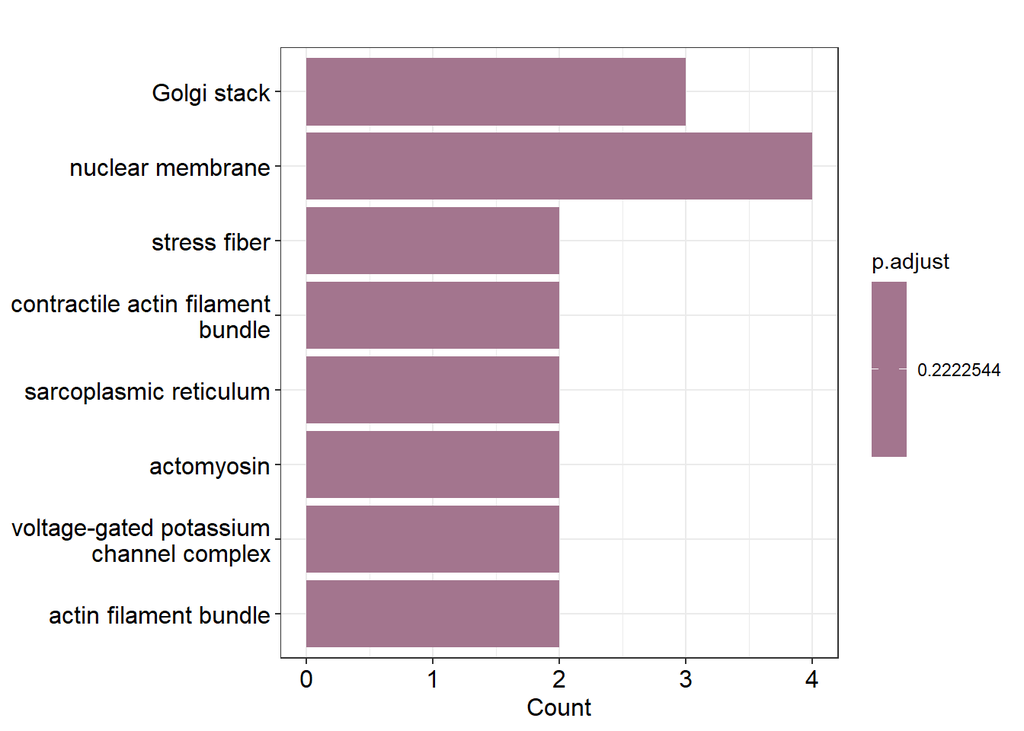

```r
barplot(eGOLasso)
```

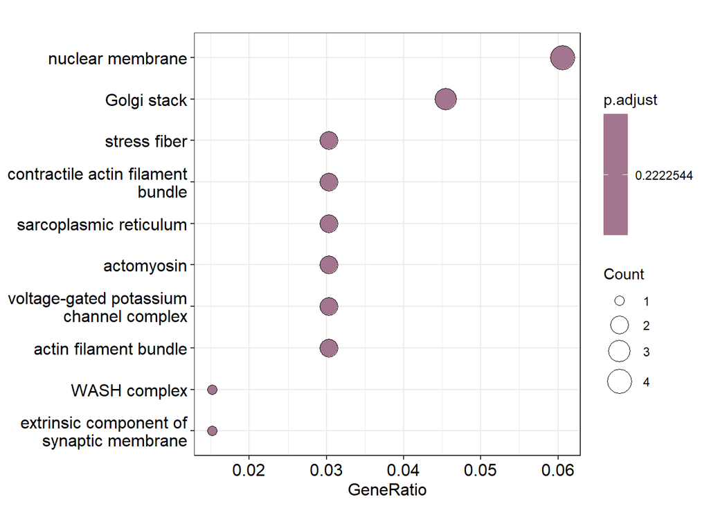

```r
dotplot(eGOLasso)
```

A continuación de manera complementaria al enriquecimiento anterior, calcularemos la matriz de similitud de terminos utilizando la función ‘pairwise_termsim()’ del paquete ‘clusterProfiler’. Esta matriz de similitud permite visualizar la relación entre los términos de enriquecimiento, lo que ayuda a identificar agrupaciones o patrones significativos entre ellos. Posteriormente, se utiliza la función ‘emapplot()’ del paquete ‘enrichplot’ para generar un gráfico basado en la matriz de similitud de términos calculada.

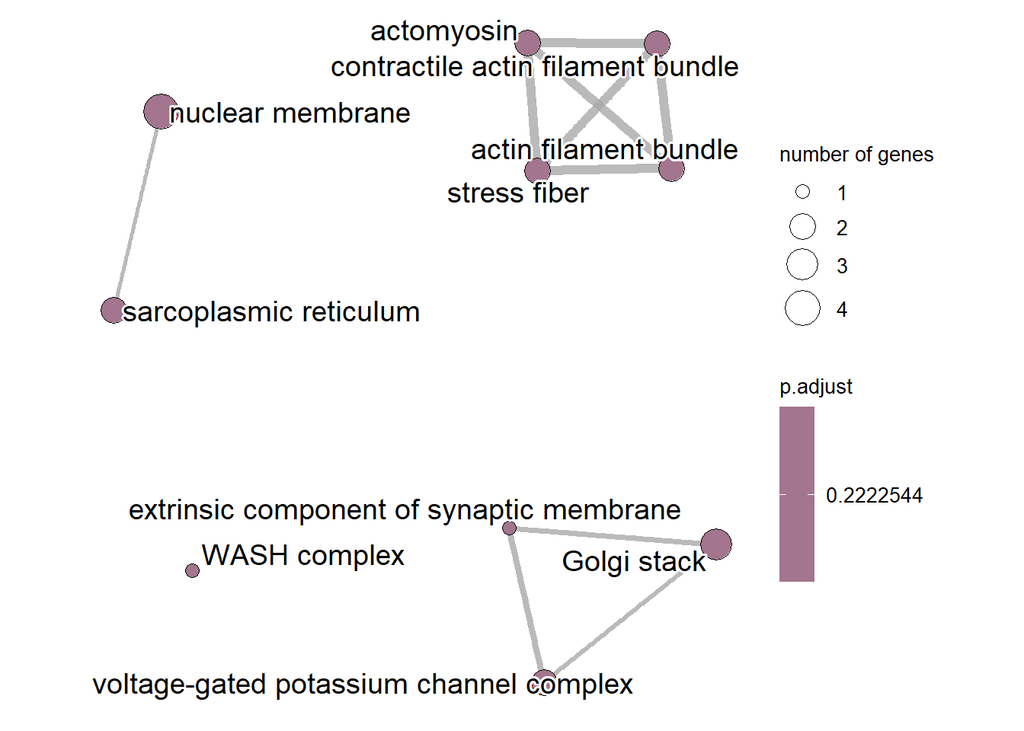

```r
# Calcular la matriz de similitud de términos
termsim <- pairwise_termsim(eGOLasso)

#Muestra el gráfico utilizando la matriz de similitud de términos calculada
enrichplot::emapplot(termsim, showCategory = 10)
```

Ahora, realizaremos un análisis de enriquecimiento de genes utilizando la base de datos de vías metabólicas de Kyoto Encyclopedia of Genes and Genomes (KEGG).Este análisis proporciona información sobre las vías metabólicas que están asociadas de manera significativa con el conjunto de genes de interés. Utilizaremos la función ‘enrichMKEGG()’ para llevar a cabo este análisis, utilizando como entrada el conjunto de genes que hemos identificado previamente. Este proceso nos proporcionará información sobre las vías metabólicas que podrían tener un papel importante en los procesos biológicos que estamos estudiando.

```r
gse <- enrichMKEGG(gene = posiciones_genes,
                   organism = 'hsa',
                   pvalueCutoff = 1.0)
```

```
## Reading KEGG annotation online: "https://rest.kegg.jp/link/hsa/module"...
```

```
## Reading KEGG annotation online: "https://rest.kegg.jp/list/module"...
```

```r
gse
```

```
## #
## # over-representation test
## #
## #...@organism     hsa
## #...@ontology     MKEGG
## #...@gene     chr [1:74] "100216546" "10142" "9331" "63891" "54981" "10529" "23093" ...
## #...pvalues adjusted by 'BH' with cutoff <1
## #...3 enriched terms found
## 'data.frame':    3 obs. of  9 variables:
##  $ ID         : chr  "M00059" "M00872" "M00089"
##  $ Description: chr  "Glycosaminoglycan biosynthesis, heparan sulfate backbone" "O-glycan biosynthesis, mannose type (core M3)" "Triacylglycerol biosynthesis"
##  $ GeneRatio  : chr  "1/5" "1/5" "1/5"
##  $ BgRatio    : chr  "10/865" "12/865" "23/865"
##  $ pvalue     : num  0.0566 0.0676 0.1263
##  $ p.adjust   : num  0.101 0.101 0.126
##  $ qvalue     : num  0.101 0.101 0.126
##  $ geneID     : chr  "2137" "10585" "154141"
##  $ Count      : int  1 1 1
## #...Citation
##  T Wu, E Hu, S Xu, M Chen, P Guo, Z Dai, T Feng, L Zhou, W Tang, L Zhan, X Fu, S Liu, X Bo, and G Yu.
##  clusterProfiler 4.0: A universal enrichment tool for interpreting omics data.
##  The Innovation. 2021, 2(3):100141
```

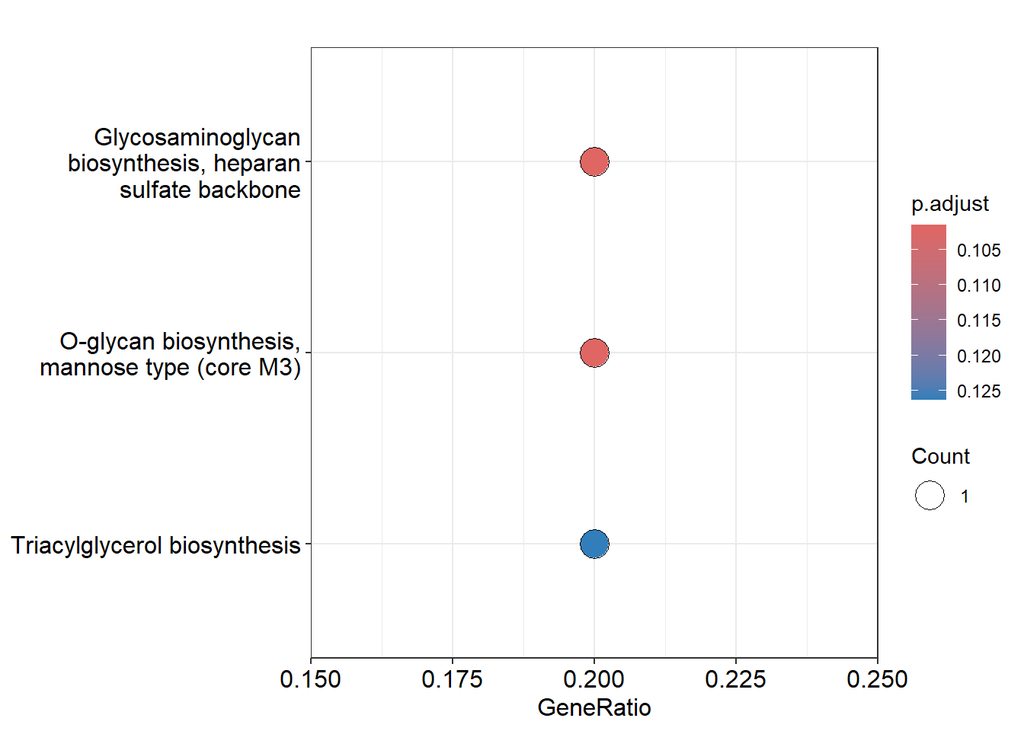

```r
dotplot(gse)
```

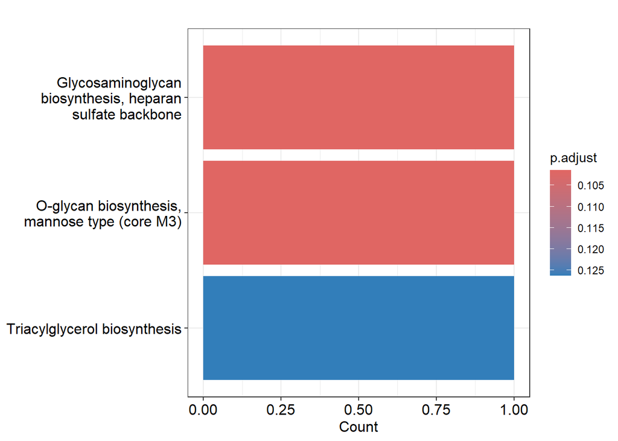

```r
barplot(gse)
```

```r
genes_BP <- enrichGO(gene     = posiciones_genes,
                     OrgDb         = org.Hs.eg.db,
                     pvalueCutoff = 1,
                     ont           = "BP",
                     readable      = TRUE)
genes_BP
```

```
## #
## # over-representation test
## #
## #...@organism     Homo sapiens
## #...@ontology     BP
## #...@keytype      ENTREZID
## #...@gene     chr [1:74] "100216546" "10142" "9331" "63891" "54981" "10529" "23093" ...
## #...pvalues adjusted by 'BH' with cutoff <1
## #...0 enriched terms found
## #...Citation
##  T Wu, E Hu, S Xu, M Chen, P Guo, Z Dai, T Feng, L Zhou, W Tang, L Zhan, X Fu, S Liu, X Bo, and G Yu.
##  clusterProfiler 4.0: A universal enrichment tool for interpreting omics data.
##  The Innovation. 2021, 2(3):100141
```

```r
genes_MF <- enrichGO(gene     = posiciones_genes,
                     OrgDb         = org.Hs.eg.db,
                     pvalueCutoff = 1,
                     ont = "MF",
                     readable      = TRUE)
genes_MF
```

```
## #
## # over-representation test
## #
## #...@organism     Homo sapiens
## #...@ontology     MF
## #...@keytype      ENTREZID
## #...@gene     chr [1:74] "100216546" "10142" "9331" "63891" "54981" "10529" "23093" ...
## #...pvalues adjusted by 'BH' with cutoff <1
## #...7 enriched terms found
## 'data.frame':    7 obs. of  9 variables:
##  $ ID         : chr  "GO:0005384" "GO:0042393" "GO:0034237" "GO:0140030" ...
##  $ Description: chr  "manganese ion transmembrane transporter activity" "histone binding" "protein kinase A regulatory subunit binding" "modification-dependent protein binding" ...
##  $ GeneRatio  : chr  "2/69" "5/69" "2/69" "4/69" ...
##  $ BgRatio    : chr  "10/18432" "258/18432" "25/18432" "172/18432" ...
##  $ pvalue     : num  0.00061 0.0028 0.00392 0.00395 0.00561 ...
##  $ p.adjust   : num  0.152 0.22 0.22 0.22 0.22 ...
##  $ qvalue     : num  0.138 0.199 0.199 0.199 0.199 ...
##  $ geneID     : chr  "ATP13A1/SLC39A8" "GLYR1/SFMBT1/ANP32E/BAZ2A/PRKCB" "AKAP9/KCNQ1" "GLYR1/OTUD7B/FAN1/BAZ2A" ...
##  $ Count      : int  2 5 2 4 2 6 4
## #...Citation
##  T Wu, E Hu, S Xu, M Chen, P Guo, Z Dai, T Feng, L Zhou, W Tang, L Zhan, X Fu, S Liu, X Bo, and G Yu.
##  clusterProfiler 4.0: A universal enrichment tool for interpreting omics data.
##  The Innovation. 2021, 2(3):100141
```

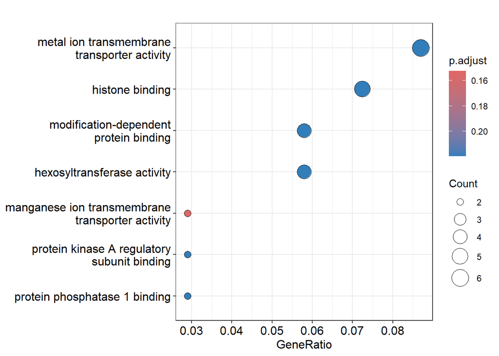

```r
dotplot(genes_MF)
```

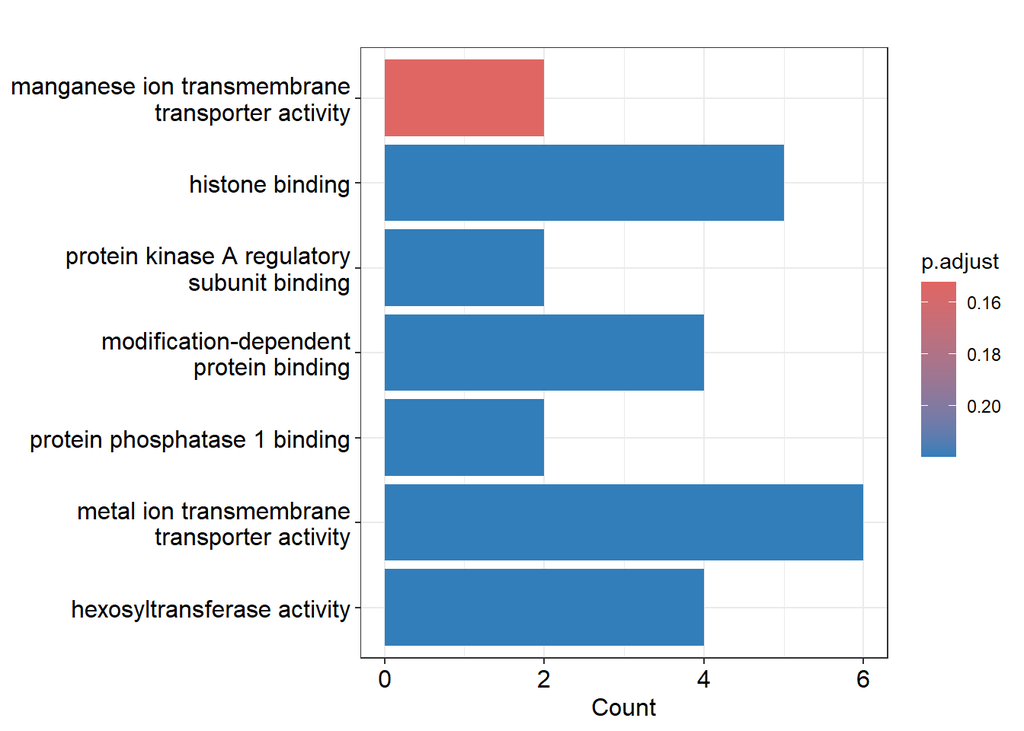

```r
barplot(genes_MF)
```

```r
genes_CC <- enrichGO(gene     = posiciones_genes,
                     OrgDb         = org.Hs.eg.db,
                     pvalueCutoff = 1,,
                     ont           = "CC",
                     readable      = TRUE)
genes_CC
```

```
## #
## # over-representation test
## #
## #...@organism     Homo sapiens
## #...@ontology     CC
## #...@keytype      ENTREZID
## #...@gene     chr [1:74] "100216546" "10142" "9331" "63891" "54981" "10529" "23093" ...
## #...pvalues adjusted by 'BH' with cutoff <1
## #...40 enriched terms found
## 'data.frame':    40 obs. of  9 variables:
##  $ ID         : chr  "GO:0005795" "GO:0031965" "GO:0001725" "GO:0097517" ...
##  $ Description: chr  "Golgi stack" "nuclear membrane" "stress fiber" "contractile actin filament bundle" ...
##  $ GeneRatio  : chr  "3/66" "4/66" "2/66" "2/66" ...
##  $ BgRatio    : chr  "153/19869" "305/19869" "70/19869" "70/19869" ...
##  $ pvalue     : num  0.0144 0.0186 0.0227 0.0227 0.0245 ...
##  $ p.adjust   : num  0.222 0.222 0.222 0.222 0.222 ...
##  $ qvalue     : num  0.184 0.184 0.184 0.184 0.184 ...
##  $ geneID     : chr  "AKAP9/B4GALT6/ZDHHC14" "RNF123/TOR1AIP2/QRICH2/TMEM38A" "NEBL/PDLIM5" "NEBL/PDLIM5" ...
##  $ Count      : int  3 4 2 2 2 2 2 2 1 1 ...
## #...Citation
##  T Wu, E Hu, S Xu, M Chen, P Guo, Z Dai, T Feng, L Zhou, W Tang, L Zhan, X Fu, S Liu, X Bo, and G Yu.
##  clusterProfiler 4.0: A universal enrichment tool for interpreting omics data.
##  The Innovation. 2021, 2(3):100141
```

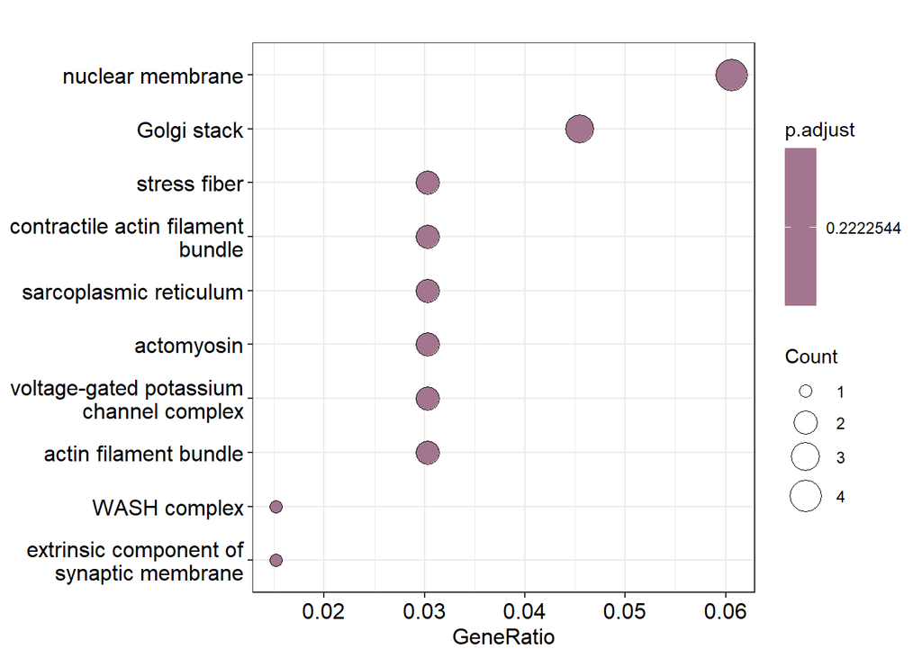

```r
dotplot(genes_CC)
```

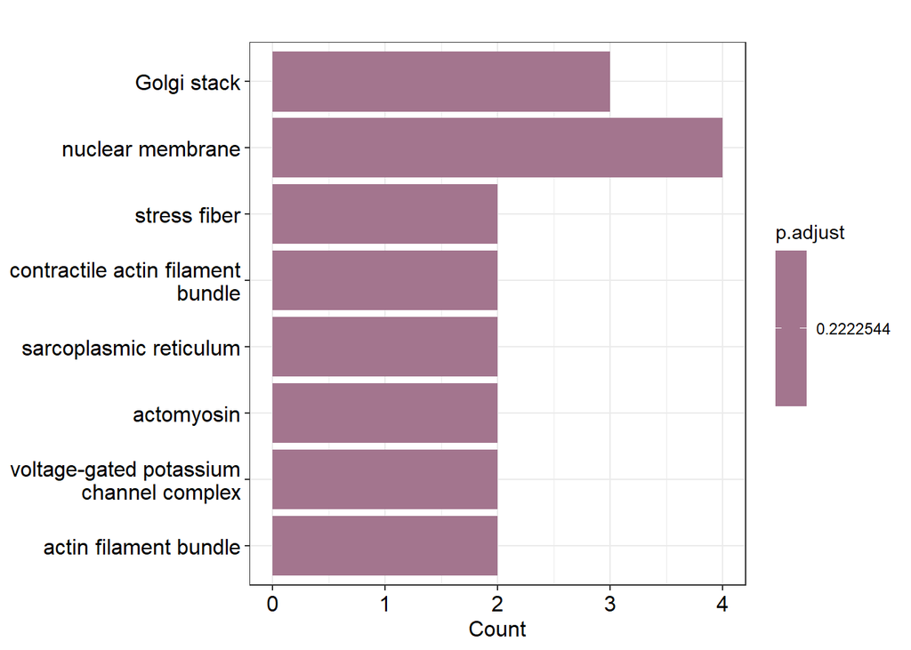

```r
barplot(genes_CC)
```

Por ultimo, utilizaremos la función ‘enrichKEGG()’ para identificar aquellas vias biologicas que se encuentran representadas por los genes obtenidos:

```r
genes_KEGG <- enrichKEGG(gene = posiciones_genes,
                         organism = 'hsa',
                         pvalueCutoff = 1)
```

```
## Reading KEGG annotation online: "https://rest.kegg.jp/link/hsa/pathway"...
```

```
## Reading KEGG annotation online: "https://rest.kegg.jp/list/pathway/hsa"...
```

```r
genes_KEGG
```

```
## #
## # over-representation test
## #
## #...@organism     hsa
## #...@ontology     KEGG
## #...@keytype      kegg
## #...@gene     chr [1:74] "100216546" "10142" "9331" "63891" "54981" "10529" "23093" ...
## #...pvalues adjusted by 'BH' with cutoff <1
## #...6 enriched terms found
## 'data.frame':    6 obs. of  9 variables:
##  $ ID         : chr  "hsa04972" "hsa04971" "hsa04727" "hsa04725" ...
##  $ Description: chr  "Pancreatic secretion" "Gastric acid secretion" "GABAergic synapse" "Cholinergic synapse" ...
##  $ GeneRatio  : chr  "4/32" "3/32" "3/32" "3/32" ...
##  $ BgRatio    : chr  "102/8764" "76/8764" "89/8764" "113/8764" ...
##  $ pvalue     : num  0.000484 0.002594 0.004059 0.007887 0.008261 ...
##  $ p.adjust   : num  0.0663 0.1777 0.1853 0.189 0.189 ...
##  $ qvalue     : num  0.0576 0.1543 0.1609 0.1641 0.1641 ...
##  $ geneID     : chr  "9545/115/3784/5579" "115/3784/5579" "81539/115/5579" "115/3784/5579" ...
##  $ Count      : int  4 3 3 3 4 3
## #...Citation
##  T Wu, E Hu, S Xu, M Chen, P Guo, Z Dai, T Feng, L Zhou, W Tang, L Zhan, X Fu, S Liu, X Bo, and G Yu.
##  clusterProfiler 4.0: A universal enrichment tool for interpreting omics data.
##  The Innovation. 2021, 2(3):100141
```

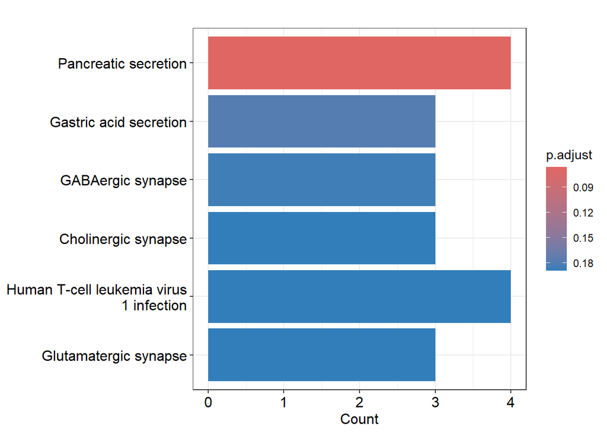

```r
barplot(genes_KEGG)
```

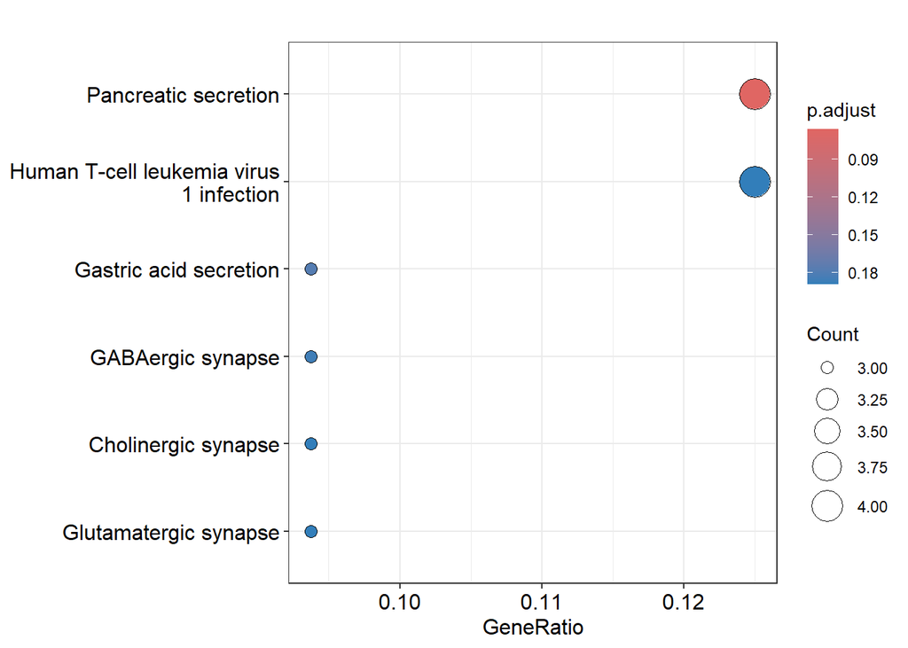

```r
dotplot(genes_KEGG)
```

## 1.2 Enriquecimiento de los datos obtenido mediante modelo Lasso+PCA

A partir del modelo denominado “lasso.mod_pca”, se llevará a cabo el enriquecimiento de los datos obtenidos siguiendo los mismos pasos llevados acabo con el modelo anterior.

```r
# Obtención de los coeficientes de las variables relevantes para el modelo
coef_pca <- coef(lasso.mod_pca, s = "lambda.min")
coef_pca_vector <- as.vector(coef_pca)
posiciones_coef_pca <- which(coef_pca != 0)
posiciones_coef_pca <- posiciones_coef_pca[-1]

# Crear un dataframe con los predictores
variables_pca <- as.data.frame(rownames(coef_pca))
colnames(variables_pca)[colnames(variables_pca) == "rownames(coef)"] <- "Variables"

# Añadir los coeficientes correspondientes
variables_pca$Coeficientes <- coef_pca_vector

# Filtrar aquellos distintos de 0 y eliminar el intercepto
predictoresLasso_pca <- variables_pca[posiciones_coef_pca, ]
predictoresLasso_pca <- predictoresLasso_pca[order(abs(predictoresLasso_pca$Coeficientes), decreasing = TRUE), ]
predictoresLasso_pca
```

|  | rownames(coef_pca) | Coeficientes |
| --- | --- | --- |
| 3 | PC2 | -8.787133e-20 |

```r
#Obtencion de los SIMBOLOS de los genes presentes en el modelo
simbolo_genes_pca <- as.vector(predictoresLasso_pca$`rownames(coef_pca)`)

# Identificación de funciones biológicas
eGOLasso_pca <- enrichGO(gene = simbolo_genes_pca,
                         OrgDb = organism,
                         ont = "all"
)
eGOLasso_pca
```

[output not shown]

```r
# Enriquecimiento de genes utilizando la base de datos de vías metabólicas de KEGG
gse_pca <- enrichMKEGG(gene = simbolo_genes_pca,
                       organism = 'hsa',
                       pvalueCutoff = 1.0)
```

```
## Reading KEGG annotation online: "https://rest.kegg.jp/link/hsa/module"...
```

```
## Reading KEGG annotation online: "https://rest.kegg.jp/list/module"...
```

```
## --> No gene can be mapped....
```

```
## --> Expected input gene ID: 6888,6390,3417,2026,2645,7086
```

```
## --> return NULL...
```

```r
gse_pca
```

```r
# Enriquecimiento GO para las categorías de BP, MF y CC
genes_BP_pca <- enrichGO(gene     = simbolo_genes_pca,
                         universe      = organism,
                         OrgDb         = org.Hs.eg.db,
                         pvalueCutoff = 1,
                         ont           = "BP",
                         readable      = TRUE)
```

```
## --> No gene can be mapped....
```

```
## --> Expected input gene ID: 1271,94027,49855,1843,5340,11331
```

```
## --> return NULL...
```

```r
genes_BP_pca
```

```r
genes_MF_pca <- enrichGO(gene     = simbolo_genes_pca,
                         universe      = organism,
                         OrgDb         = org.Hs.eg.db,
                         pvalueCutoff = 1,
                         ont = "MF",
                         readable      = TRUE)
```

```
## --> No gene can be mapped....
```

```
## --> Expected input gene ID: 57107,2687,2072,440138,23590,644974
```

```
## --> return NULL...
```

```r
genes_MF_pca
```

```r
genes_CC_pca <- enrichGO(gene     = simbolo_genes_pca,
                         universe      = organism,
                         OrgDb         = org.Hs.eg.db,
                         pvalueCutoff = 1,
                         ont           = "CC",
                         readable      = TRUE)
```

```
## --> No gene can be mapped....
```

```
## --> Expected input gene ID: 23774,6314,1810,51147,9611,57634
```

```
## --> return NULL...
```

```r
genes_CC_pca
```

## 1.3 Enriquecimiento de los datos obtenido mediante modelo Lasso a partir de los datos filtrados

A partir del modelo denominado “lasso.mod_f”, se llevará a cabo el enriquecimiento de los datos obtenidos siguiendo los mismos pasos llevados acabo con el modelo anterior.

```r
# Obtención de los coeficientes de las variables relevantes para el modelo
coef_f <- coef(lasso.mod_f, s = "lambda.min")
coef_f_vector <- as.vector(coef_f)
posiciones_f_coef <- which(coef_f != 0)
posiciones_f_coef <- posiciones_f_coef[-1]

# Crear un dataframe con los predictores
variables_f <- as.data.frame(rownames(coef_f))
colnames(variables_f)[colnames(variables_f) == "rownames(coef)"] <- "Variables"

# Añadir los coeficientes correspondientes
variables_f$Coeficientes <- coef_f_vector

# Filtrar aquellos distintos de 0 y eliminar el intercepto
predictoresLasso_f <- variables_f[posiciones_f_coef, ]
predictoresLasso_f <- predictoresLasso_f[order(abs(predictoresLasso_f$Coeficientes), decreasing = TRUE), ]
predictoresLasso_f
```

|  | rownames(coef_f) | Coeficientes |
| --- | --- | --- |
| 992 | LINC01004 | 0.1666475255 |
| 77 | AKAP9 | 0.1239415682 |
| 690 | FCGBP | -0.0925863136 |
| 259 | C5orf15 | -0.0732967716 |
| 1642 | SATB1.AS1 | -0.0652177478 |
| 457 | CUL9 | 0.0593998088 |
| 2206 | ZDHHC14 | -0.0496264790 |
| 2114 | UTY | 0.0458308179 |
| 1698 | SH2B3 | -0.0394683047 |
| 1262 | NUB1 | -0.0321916363 |

[output cut: 42 more lines]

```r
#Obtencion de los ENTREZID de los genes presentes en el modelo
simbolo_genes_f <- as.vector(predictoresLasso_f$`rownames(coef_f)`)
entrez_ids_f <- select(org.Hs.eg.db, keys=simbolo_genes_f, keytype="SYMBOL", column="ENTREZID")
posiciones_genes_f <- as.numeric(entrez_ids_f$ENTREZID)

# Identificación de funciones biológicas
eGOLasso_f <- enrichGO(gene = posiciones_genes_f,
                       OrgDb = organism,
                       pvalueCutoff = 1,
                       keyType = "ENTREZID",
                       ont = "all"
)
eGOLasso_f
```

```
## #
## # over-representation test
## #
## #...@organism     Homo sapiens
## #...@ontology     GOALL
## #...@keytype      ENTREZID
## #...@gene     chr [1:48] "100216546" "10142" "8857" "56951" NA "23113" "79683" "7404" ...
## #...pvalues adjusted by 'BH' with cutoff <1
## #...12 enriched terms found
## 'data.frame':    12 obs. of  10 variables:
##  $ ONTOLOGY   : chr  "BP" "BP" "BP" "BP" ...
##  $ ID         : chr  "GO:0034198" "GO:1990928" "GO:0009267" "GO:0042594" ...
##  $ Description: chr  "cellular response to amino acid starvation" "response to amino acid starvation" "cellular response to starvation" "response to starvation" ...
##  $ GeneRatio  : chr  "3/39" "3/39" "4/39" "4/39" ...
##  $ BgRatio    : chr  "49/18903" "51/18903" "175/18903" "211/18903" ...
##  $ pvalue     : num  0.00014 0.000158 0.000453 0.000914 0.001278 ...
##  $ p.adjust   : num  0.0656 0.0656 0.1256 0.1898 0.2084 ...
##  $ qvalue     : num  0.0607 0.0607 0.1163 0.1758 0.1929 ...
##  $ geneID     : chr  "10985/5610/8131" "10985/5610/8131" "10985/5610/8131/3428" "10985/5610/8131/3428" ...
##  $ Count      : int  3 3 4 4 4 3 2 2 2 2 ...
## #...Citation
##  T Wu, E Hu, S Xu, M Chen, P Guo, Z Dai, T Feng, L Zhou, W Tang, L Zhan, X Fu, S Liu, X Bo, and G Yu.
##  clusterProfiler 4.0: A universal enrichment tool for interpreting omics data.
##  The Innovation. 2021, 2(3):100141
```

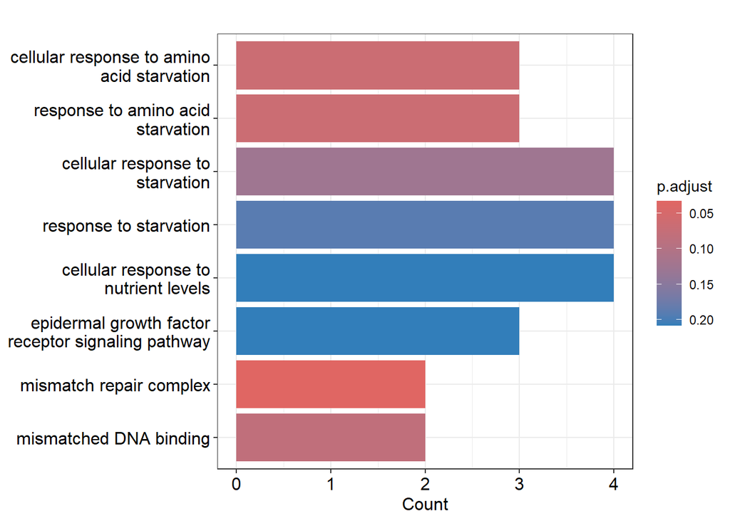

```r
barplot(eGOLasso_f)
```

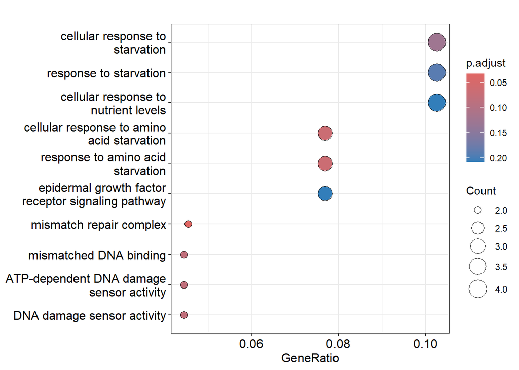

```r
dotplot(eGOLasso_f)
```

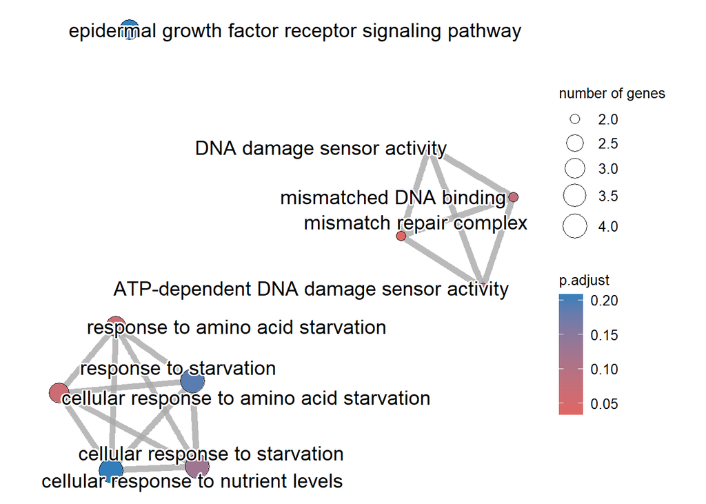

```r
# Calcular la matriz de similitud de términos
termsim_f <- pairwise_termsim(eGOLasso_f)

# Muestra el gráfico utilizando la matriz de similitud de términos calculada
enrichplot::emapplot(termsim_f, showCategory = 10)
```

```r
# Enriquecimiento de genes utilizando la base de datos de vías metabólicas de KEGG
gse_f <- enrichMKEGG(gene = posiciones_genes_f,
                     organism = 'hsa',
                     pvalueCutoff = 1.0)
gse_f
```

```
## #
## # over-representation test
## #
## #...@organism     hsa
## #...@ontology     MKEGG
## #...@gene     chr [1:48] "100216546" "10142" "8857" "56951" NA "23113" "79683" "7404" ...
## #...pvalues adjusted by 'BH' with cutoff <1
## #...1 enriched terms found
## 'data.frame':    1 obs. of  9 variables:
##  $ ID         : chr "M00059"
##  $ Description: chr "Glycosaminoglycan biosynthesis, heparan sulfate backbone"
##  $ GeneRatio  : chr "1/1"
##  $ BgRatio    : chr "10/865"
##  $ pvalue     : num 0.0116
##  $ p.adjust   : num 0.0116
##  $ qvalue     : logi NA
##  $ geneID     : chr "2137"
##  $ Count      : int 1
## #...Citation
##  T Wu, E Hu, S Xu, M Chen, P Guo, Z Dai, T Feng, L Zhou, W Tang, L Zhan, X Fu, S Liu, X Bo, and G Yu.
##  clusterProfiler 4.0: A universal enrichment tool for interpreting omics data.
##  The Innovation. 2021, 2(3):100141
```

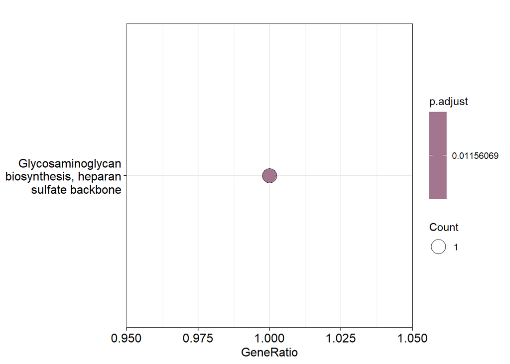

```r
dotplot(gse_f)
```

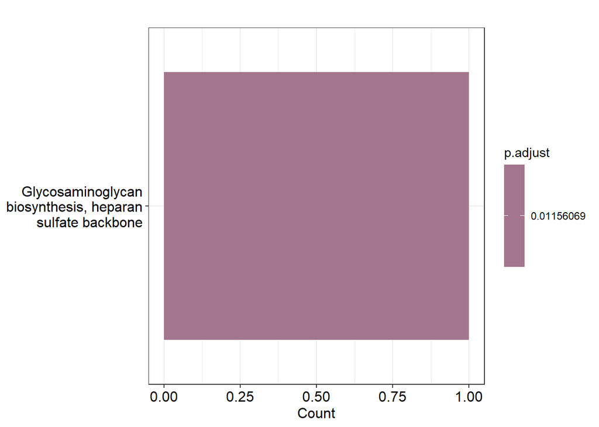

```r
barplot(gse_f)
```

```r
# Enriquecimiento GO para las categorías de BP, MF y CC
genes_BP_f <- enrichGO(gene     = posiciones_genes_f,
                       OrgDb         = org.Hs.eg.db,
                       pvalueCutoff = 1,
                       ont           = "BP",
                       readable      = TRUE)
genes_BP_f
```

```
## #
## # over-representation test
## #
## #...@organism     Homo sapiens
## #...@ontology     BP
## #...@keytype      ENTREZID
## #...@gene     chr [1:48] "100216546" "10142" "8857" "56951" NA "23113" "79683" "7404" ...
## #...pvalues adjusted by 'BH' with cutoff <1
## #...6 enriched terms found
## 'data.frame':    6 obs. of  9 variables:
##  $ ID         : chr  "GO:0034198" "GO:1990928" "GO:0009267" "GO:0042594" ...
##  $ Description: chr  "cellular response to amino acid starvation" "response to amino acid starvation" "cellular response to starvation" "response to starvation" ...
##  $ GeneRatio  : chr  "3/39" "3/39" "4/39" "4/39" ...
##  $ BgRatio    : chr  "49/18903" "51/18903" "175/18903" "211/18903" ...
##  $ pvalue     : num  0.00014 0.000158 0.000453 0.000914 0.001278 ...
##  $ p.adjust   : num  0.0656 0.0656 0.1256 0.1898 0.2084 ...
##  $ qvalue     : num  0.0607 0.0607 0.1163 0.1758 0.1929 ...
##  $ geneID     : chr  "GCN1/EIF2AK2/NPRL3" "GCN1/EIF2AK2/NPRL3" "GCN1/EIF2AK2/NPRL3/IFI16" "GCN1/EIF2AK2/NPRL3/IFI16" ...
##  $ Count      : int  3 3 4 4 4 3
## #...Citation
##  T Wu, E Hu, S Xu, M Chen, P Guo, Z Dai, T Feng, L Zhou, W Tang, L Zhan, X Fu, S Liu, X Bo, and G Yu.
##  clusterProfiler 4.0: A universal enrichment tool for interpreting omics data.
##  The Innovation. 2021, 2(3):100141
```

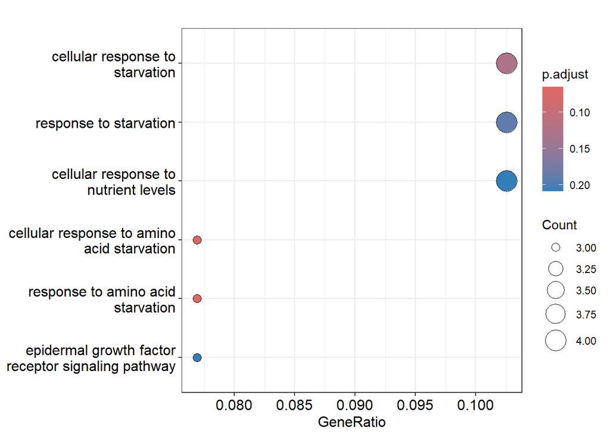

```r
dotplot(genes_BP_f)
```

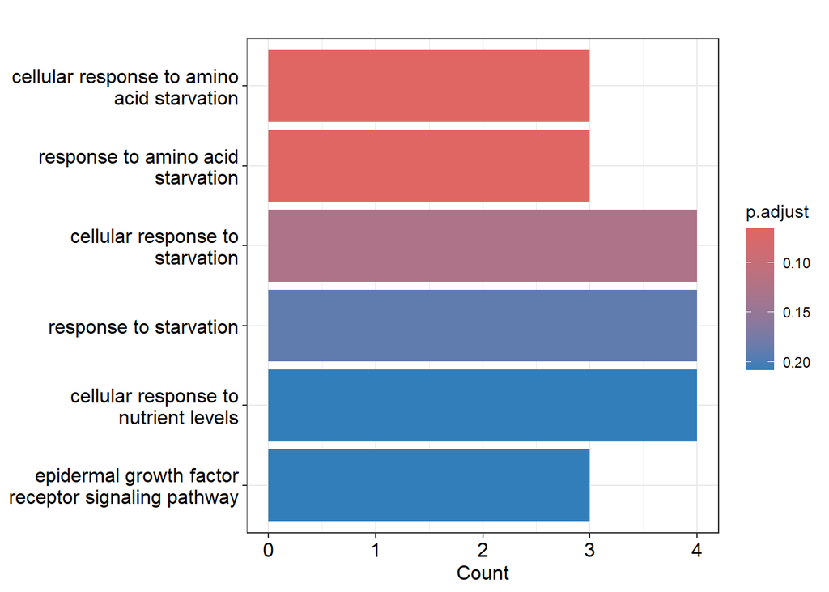

```r
barplot(genes_BP_f)
```

```r
genes_MF_f <- enrichGO(gene     = posiciones_genes_f,
                       OrgDb         = org.Hs.eg.db,
                       pvalueCutoff = 1,
                       ont = "MF",
                       readable      = TRUE)
genes_MF_f
```

```
## #
## # over-representation test
## #
## #...@organism     Homo sapiens
## #...@ontology     MF
## #...@keytype      ENTREZID
## #...@gene     chr [1:48] "100216546" "10142" "8857" "56951" NA "23113" "79683" "7404" ...
## #...pvalues adjusted by 'BH' with cutoff <1
## #...5 enriched terms found
## 'data.frame':    5 obs. of  9 variables:
##  $ ID         : chr  "GO:0030983" "GO:0140664" "GO:0140612" "GO:0140299" ...
##  $ Description: chr  "mismatched DNA binding" "ATP-dependent DNA damage sensor activity" "DNA damage sensor activity" "small molecule sensor activity" ...
##  $ GeneRatio  : chr  "2/45" "2/45" "2/45" "2/45" ...
##  $ BgRatio    : chr  "14/18432" "21/18432" "24/18432" "37/18432" ...
##  $ pvalue     : num  0.000521 0.001188 0.001555 0.003676 0.004939
##  $ p.adjust   : num  0.0819 0.0819 0.0819 0.1452 0.1561
##  $ qvalue     : num  0.0742 0.0742 0.0742 0.1316 0.1414
##  $ geneID     : chr  "MLH3/PMS1" "MLH3/PMS1" "MLH3/PMS1" "MLH3/PMS1" ...
##  $ Count      : int  2 2 2 2 2
## #...Citation
##  T Wu, E Hu, S Xu, M Chen, P Guo, Z Dai, T Feng, L Zhou, W Tang, L Zhan, X Fu, S Liu, X Bo, and G Yu.
##  clusterProfiler 4.0: A universal enrichment tool for interpreting omics data.
##  The Innovation. 2021, 2(3):100141
```

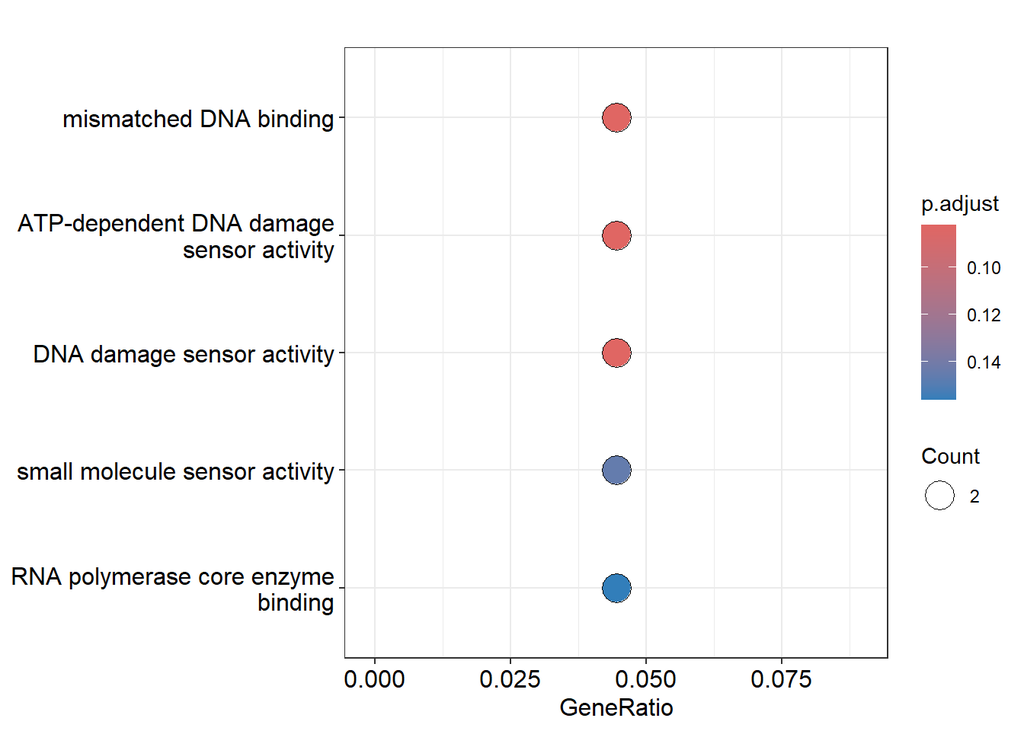

```r
dotplot(genes_MF_f)
```

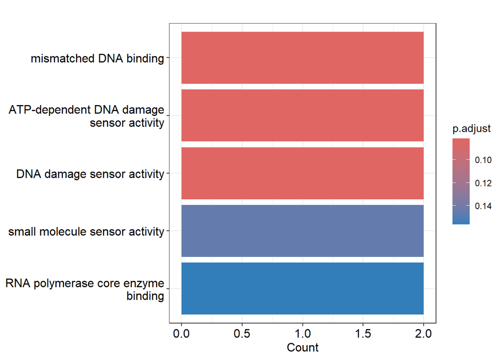

```r
barplot(genes_MF_f)
```

```r
genes_CC_f <- enrichGO(gene     = posiciones_genes_f,
                       OrgDb         = org.Hs.eg.db,
                       pvalueCutoff = 1,
                       ont           = "CC",
                       readable      = TRUE)
genes_CC_f
```

```
## #
## # over-representation test
## #
## #...@organism     Homo sapiens
## #...@ontology     CC
## #...@keytype      ENTREZID
## #...@gene     chr [1:48] "100216546" "10142" "8857" "56951" NA "23113" "79683" "7404" ...
## #...pvalues adjusted by 'BH' with cutoff <1
## #...1 enriched terms found
## 'data.frame':    1 obs. of  9 variables:
##  $ ID         : chr "GO:0032300"
##  $ Description: chr "mismatch repair complex"
##  $ GeneRatio  : chr "2/44"
##  $ BgRatio    : chr "12/19869"
##  $ pvalue     : num 0.000312
##  $ p.adjust   : num 0.0331
##  $ qvalue     : num 0.0315
##  $ geneID     : chr "MLH3/PMS1"
##  $ Count      : int 2
## #...Citation
##  T Wu, E Hu, S Xu, M Chen, P Guo, Z Dai, T Feng, L Zhou, W Tang, L Zhan, X Fu, S Liu, X Bo, and G Yu.
##  clusterProfiler 4.0: A universal enrichment tool for interpreting omics data.
##  The Innovation. 2021, 2(3):100141
```

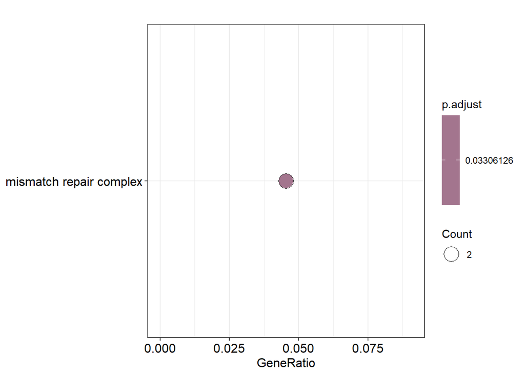

```r
dotplot(genes_CC_f)
```

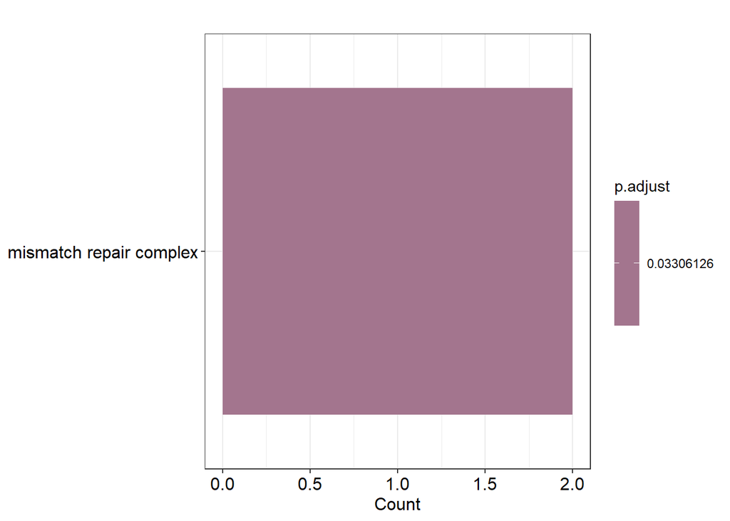

```r
barplot(genes_CC_f)
```

## 1.4 Enriquecimiento de los datos obtenido mediante modelo Lasso a partir de los datos filtrados + PCA

A partir del modelo denominado “lasso.mod_pca_f”, se llevará a cabo el enriquecimiento de los datos obtenidos siguiendo los mismos pasos llevados acabo con el modelo anterior.

```r
# Obtención de los coeficientes de las variables relevantes para el modelo
coef_pca_f <- coef(lasso.mod_pca_f, s = "lambda.min")
coef_vector_pca_f <- as.vector(coef_pca_f)
posiciones_coef_pca_f <- which(coef_pca_f != 0)
posiciones_coef_pca_f <- posiciones_coef_pca_f[-1]

# Crear un dataframe con los predictores
variables_pca_f <- as.data.frame(rownames(coef_pca_f))
colnames(variables_pca_f)[colnames(variables_pca_f) == "rownames(coef)"] <- "Variables"

# Añadir los coeficientes correspondientes
variables_pca_f$Coeficientes <- coef_vector_pca_f

# Filtrar aquellos distintos de 0 y eliminar el intercepto
predictoresLasso_pca_f <- variables_pca_f[posiciones_coef_pca_f, ]
predictoresLasso_pca_f <- predictoresLasso_pca_f[order(abs(predictoresLasso_pca_f$Coeficientes), decreasing = TRUE), ]
predictoresLasso_pca_f
```

|  | rownames(coef_pca_f) | Coeficientes |
| --- | --- | --- |
| 3 | PC2 | -0.0002312745 |

```r
#Obtencion de los SIMBOLOS de los genes presentes en el modelo
simbolo_genes_pca_f <- as.character(predictoresLasso_pca_f$`rownames(coef_pca_f)`)

# Enriquecimiento de genes utilizando la base de datos de vías metabólicas de KEGG
gse_pca_f <- enrichMKEGG(gene = simbolo_genes_pca_f,
                         organism = 'hsa',
                         pvalueCutoff = 1.0)
```

```
## --> No gene can be mapped....
```

```
## --> Expected input gene ID: 83440,3098,5634,2023,229,5105
```

```
## --> return NULL...
```

```r
gse_pca_f
```

```r
# Enriquecimiento GO para las categorías de BP, MF y CC
genes_BP_pca_f <- enrichGO(gene     = simbolo_genes_pca_f,
                           universe      = organism,
                           OrgDb         = org.Hs.eg.db,
                           pvalueCutoff = 1,
                           ont           = "BP",
                           readable      = TRUE)
```

```
## --> No gene can be mapped....
```

```
## --> Expected input gene ID: 5724,23742,79733,6654,7490,9183
```

```
## --> return NULL...
```

```r
genes_BP_pca_f
```

```r
genes_MF_pca_f <- enrichGO(gene     = simbolo_genes_pca_f,
                           universe      = organism,
                           OrgDb         = org.Hs.eg.db,
                           pvalueCutoff = 1,
                           ont = "MF",
                           readable      = TRUE)
```

```
## --> No gene can be mapped....
```

```
## --> Expected input gene ID: 644974,4361,147991,5932,93183,10195
```

```
## --> return NULL...
```

```r
genes_MF_pca_f
```

```r
genes_CC_pca_f <- enrichGO(gene     = simbolo_genes_pca_f,
                           universe      = organism,
                           OrgDb         = org.Hs.eg.db,
                           pvalueCutoff = 1,
                           ont           = "CC",
                           readable      = TRUE)
```

```
## --> No gene can be mapped....
```

```
## --> Expected input gene ID: 26038,83443,3066,79101,51742,23338
```

```
## --> return NULL...
```

```r
genes_CC_pca_f
```